# Water Quality Presentation2

Group 3: Stephanie Fissel, Beza Gashe, Claire Yoon

January 4, 2023

#### Read in the data

```r
#water_quality <- read.csv("/Users/stephaniefissel/Library/Mobile Documents/com~apple~CloudDocs/ds final project/water_potability.csv")
water_quality <- read.csv("~/Desktop/R/water-quality-project/water_potability.csv")

#head(water_quality)
#dim(water_quality)
```

### Clean the data

There were 1/3 missing values in Sulfate variable, but we didn’t delete it because sulfate showed one of the crucial factors for predicting non-potability because it leads to diarrhea and some problems. After handling with the missing values, we have 2011 objects.

```r
water_quality <- water_quality[complete.cases(water_quality), ]
#dim(water_quality)
```

### Rename and factorize the ‘Potability’ variable

We renamed the categorical values (1 and 0) to “potable” and “non_potable”  
We are focusing on non potability of drinking water, so our positive value is “non_potable”

```r
water_quality$Potability <- as.factor(water_quality$Potability)
water_quality$Potability <- fct_collapse(water_quality$Potability,
                           potable = "1",
                           non_potable = "0")
```

### Splitting the data with tuning and test & Creating Decision Trees

#### First Decision Tree Model

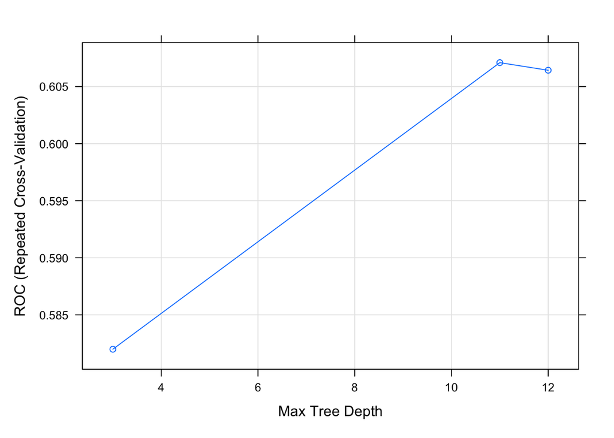

```r
#We do not need to check for correlated variables because correlation does not impact decision trees.
#Decision trees make greedy, localized decisions that are not dependent on previous steps or other variables in the tree model.
set.seed(777)
partition <- caret::createDataPartition(water_quality$Potability,
                                           times=1,
                                           p = 0.80,
                                           groups=1,
                                           list=FALSE)
train <- water_quality[partition, ]
tune_and_test <- water_quality[-partition, ]
#train

tune_and_test_index <- createDataPartition(tune_and_test$Potability,
                                           p = .5,
                                           list = FALSE,
                                           times = 1)

tune <- tune_and_test[tune_and_test_index, ]
test <- tune_and_test[-tune_and_test_index, ]

#dim(train)
#dim(test)
#dim(tune)

# Build the model
# Choose the features and classes, slightly different approach for caret, need to create features and target sets from the training data.
#str(water_quality)
features <- train[,-10] # dropping the target variable
target <- train$Potability
#str(features)

#str(target)
fitControl <- trainControl(method = "repeatedcv",
                          number = 10,
                          repeats = 5,
                          classProbs = TRUE,
                          summaryFunction = twoClassSummary)

tree.grid <- expand.grid(maxdepth=c(1:6))

# Train the model without setting tree grid
set.seed(777)
water_mdl1 <- train(x=features,
                y=target,
                method="rpart2",
                trControl=fitControl,
                metric="ROC")
plot(water_mdl1)
```

```r
varImp(water_mdl1)
```

```
## rpart2 variable importance
##
##                 Overall
## ph              100.000
## Sulfate          81.225
## Chloramines      55.675
## Hardness         55.425
## Solids           55.415
## Trihalomethanes  22.920
## Conductivity     19.896
## Turbidity         2.489
## Organic_carbon    0.000
```

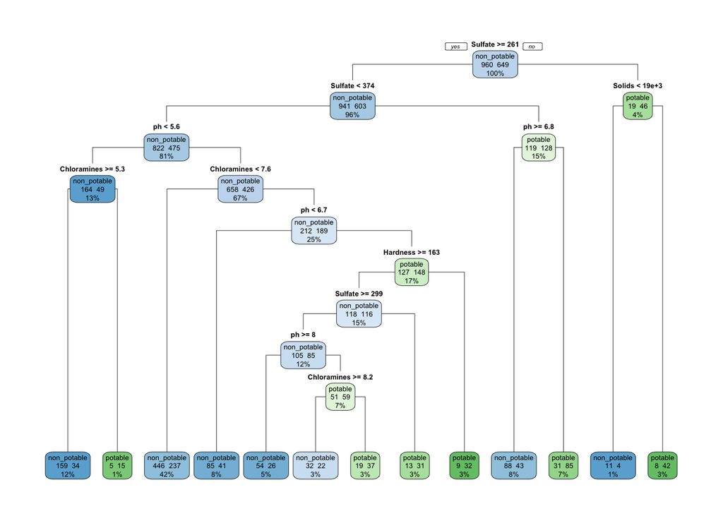

```r
rpart.plot(water_mdl1$finalModel, type=1,extra=101)
```

```r
water_mdl1 # maxdepth is 11
```

```
## CART
##
## 1609 samples
##    9 predictor
##    2 classes: 'non_potable', 'potable'
##
## No pre-processing
## Resampling: Cross-Validated (10 fold, repeated 5 times)
## Summary of sample sizes: 1448, 1448, 1448, 1448, 1448, 1448, ...
## Resampling results across tuning parameters:
##
##   maxdepth  ROC        Sens       Spec
##    3        0.5819893  0.8922917  0.2486827
##   11        0.6070960  0.8260417  0.3445192
##   12        0.6064304  0.8304167  0.3387212
##
## ROC was used to select the optimal model using the largest value.
## The final value used for the model was maxdepth = 11.
```

#### Second Decision Tree Model

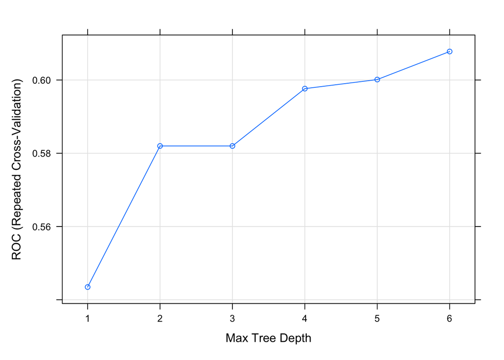

```r
# Train the model
set.seed(777)
water_mdl2 <- train(x=features,
                y=target,
                method="rpart2",
                trControl=fitControl,
                tuneGrid=tree.grid,
                metric="ROC")

plot(water_mdl2)
```

```r
varImp(water_mdl2)
```

```
## rpart2 variable importance
##
##                 Overall
## ph              100.000
## Sulfate          75.630
## Chloramines      56.055
## Solids           55.379
## Hardness         47.793
## Trihalomethanes  26.922
## Conductivity      8.764
## Turbidity         4.527
## Organic_carbon    0.000
```

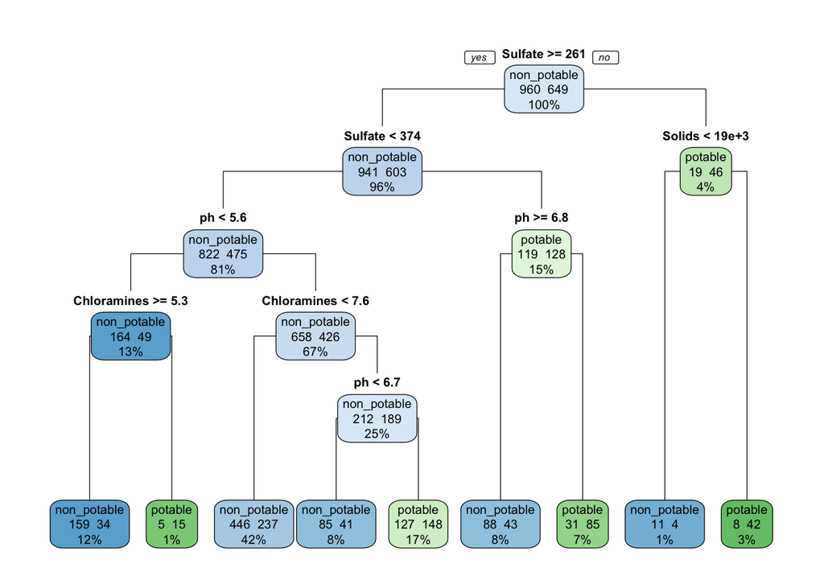

```r
rpart.plot(water_mdl2$finalModel, type=1,extra=101)
```

```r
water_mdl2 # maxdepth is 6
```

```
## CART
##
## 1609 samples
##    9 predictor
##    2 classes: 'non_potable', 'potable'
##
## No pre-processing
## Resampling: Cross-Validated (10 fold, repeated 5 times)
## Summary of sample sizes: 1448, 1448, 1448, 1448, 1448, 1448, ...
## Resampling results across tuning parameters:
##
##   maxdepth  ROC        Sens       Spec
##   1         0.5434693  0.9381250  0.1411250
##   2         0.5819893  0.8922917  0.2486827
##   3         0.5819893  0.8922917  0.2486827
##   4         0.5976481  0.8491667  0.3093990
##   5         0.6001289  0.8375000  0.3226971
##   6         0.6077882  0.8372917  0.3266827
##
## ROC was used to select the optimal model using the largest value.
## The final value used for the model was maxdepth = 6.
```

### Confusion Matrix, Statistics, and Density Plot on Two Decision Trees

#### First Model

```r
predictandCM<- function(model,data,modeltype,ref)
{
  pred <-predict(model,data,type=modeltype)
  confusionMatrix(pred, reference=ref, positive = 'non_potable')
}

predictandCM(water_mdl1, tune, "raw", tune$Potability)
```

```
## Confusion Matrix and Statistics
##
##              Reference
## Prediction    non_potable potable
##   non_potable         111      54
##   potable               9      27
##
##                Accuracy : 0.6866
##                  95% CI : (0.6175, 0.75)
##     No Information Rate : 0.597
##     P-Value [Acc > NIR] : 0.005413
##
##                   Kappa : 0.284
##
##  Mcnemar's Test P-Value : 2.965e-08
##
##             Sensitivity : 0.9250
##             Specificity : 0.3333
##          Pos Pred Value : 0.6727
##          Neg Pred Value : 0.7500
##              Prevalence : 0.5970
##          Detection Rate : 0.5522
##    Detection Prevalence : 0.8209
##       Balanced Accuracy : 0.6292
##
##        'Positive' Class : non_potable
##
```

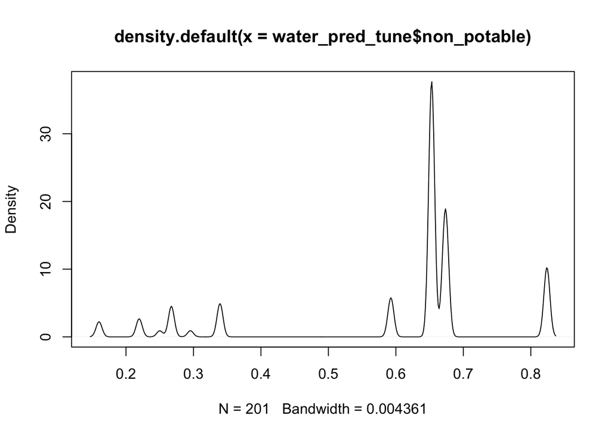

```r
water_pred_tune = predict(water_mdl1,tune,tune$Potability, type= "prob")
water_pred_tune_labels = predict(water_mdl1,tune,tune$Potability,type = "raw")
plot(density(water_pred_tune$non_potable))
```

#### Second Model

```r
predictandCM(water_mdl2, tune, "raw", tune$Potability)
```

```
## Confusion Matrix and Statistics
##
##              Reference
## Prediction    non_potable potable
##   non_potable          95      47
##   potable              25      34
##
##                Accuracy : 0.6418
##                  95% CI : (0.5713, 0.708)
##     No Information Rate : 0.597
##     P-Value [Acc > NIR] : 0.11030
##
##                   Kappa : 0.2212
##
##  Mcnemar's Test P-Value : 0.01333
##
##             Sensitivity : 0.7917
##             Specificity : 0.4198
##          Pos Pred Value : 0.6690
##          Neg Pred Value : 0.5763
##              Prevalence : 0.5970
##          Detection Rate : 0.4726
##    Detection Prevalence : 0.7065
##       Balanced Accuracy : 0.6057
##
##        'Positive' Class : non_potable
##
```

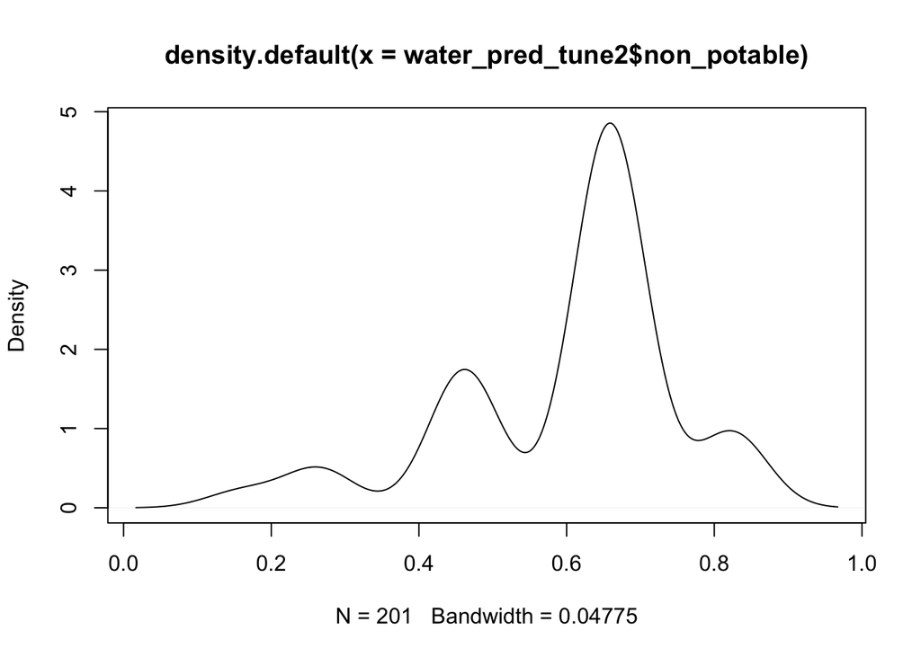

```r
water_pred_tune2 = predict(water_mdl2,tune,tune$Potability, type= "prob")
water_pred_tune_labels2 = predict(water_mdl2,tune,tune$Potability,type = "raw")
plot(density(water_pred_tune2$non_potable))
```

```r
#View(as_tibble(water_pred_tune_labels))
```

### Understanding Confusion Matrix

True Positive(TP)  
- Predicted condition: non-potable  
- Actual condition: non-potable  
False Positive(FP)  
- Predicted condition: non-potable  
- Actual condition: potable  
False Negative(FN)  
- Predicted condition: potable  
- Actual condition: non-potable  
True Negative(TN)  
- Predicted condition: potable  
- Actual condition: potable  
Considering the real world, False Positive doesn’t really make any problems because people do not drink water if it is predicted as non-potable even though it is potable. However, the opposite case (False Negative) will cause significant problems (people will be sick), so we need to make sure to reduce False Negative portion and the model should be reliable.

```r
# Use the the confusion matrix function on your predictions to check a variety of metrics and comment on the metric that might be best for this type of analysis given your question.

water_eval <- caret::confusionMatrix(water_pred_tune_labels2,
                as.factor(tune$Potability),
                dnn=c("Prediction", "Actual"),
                positive="non_potable",
                mode = "everything")
#water_eval
```

### Adjusting Threshold with the Second Decision Tree Model

We were adjusting threshold between 0.2 and 0.8, then found 0.6 is a good point considering the balance of sensitivity and specificity. However, the accuracy of the model is still low, so we need to improve on our model and reduce the False Negative values.

```r
# With the percentages you generated in step 10,select several different threshold levels using the threshold function we created and interpret the results. What patterns do you notice, did the evaluation metrics change?

adjust_thres <- function(x, y, z) {
  #x=pred_probablities, y=threshold, z=tune_outcome
  thres <- as.factor(ifelse(x > y, "non_potable","potable"))
  confusionMatrix(thres, z, positive = "non_potable", dnn=c("Prediction", "Actual"), mode = "everything")
}

adjust_thres(water_pred_tune2$non_potable,y=.6,tune$Potability)
```

```
## Confusion Matrix and Statistics
##
##              Actual
## Prediction    non_potable potable
##   non_potable          95      47
##   potable              25      34
##
##                Accuracy : 0.6418
##                  95% CI : (0.5713, 0.708)
##     No Information Rate : 0.597
##     P-Value [Acc > NIR] : 0.11030
##
##                   Kappa : 0.2212
##
##  Mcnemar's Test P-Value : 0.01333
##
##             Sensitivity : 0.7917
##             Specificity : 0.4198
##          Pos Pred Value : 0.6690
##          Neg Pred Value : 0.5763
##               Precision : 0.6690
##                  Recall : 0.7917
##                      F1 : 0.7252
##              Prevalence : 0.5970
##          Detection Rate : 0.4726
##    Detection Prevalence : 0.7065
##       Balanced Accuracy : 0.6057
##
##        'Positive' Class : non_potable
##
```